# Writeup21: trailblazing round of the Gini and heterogeneity sweeps

Kevin Z. Lin (drafted by Claude)

2026-09-23

# 1 Overview

This report summarizes the **trailblazing round** of the two simulation sweeps designed in `simulation_design_claude.md` (the design memo) for Figure 4 of the Nature Methods submission of *Resolution of Selection Versus Adaptation in Cellular Evolution*. The round ran on the laptop in three passes:

1. **10-PC pass** (2026-09-22): the memo as first written; kept as the record of why the embedding dimension matters.
2. **20-PC pass** (2026-09-22, suffix `_pca20`): the variant the first pass showed to be necessary (Section 7.7); kept as the record behind the review decisions.
3. **`_r2` pass** (2026-09-23): the design as settled after Kevin’s review of the first two passes — 20 PCs, the Gini ladder re-spaced to {0.3, …, 0.9}, t1 cells of extinct clones excluded from CoSPAR, the split-half reliability dropped — plus the Section 7 label-permutation check and UMAPs of example datasets. **All headline results below are this pass.**

Every number below is read from the CSVs in `csv/kevin/Writeup21/`; the figures in `fig/kevin/Writeup21/` are re-drawn here from the same tables.

| Stage | What it does | Where |
| --- | --- | --- |
| Generate | Hierarchical latent states, one causal coordinate, negative-binomial counts for t1 cells and their t2 children | `func_generate_claude.R` |
| Calibrate | `h²` from the AED target, `s` bisected for the Gini target, `h²` re-centred on the realized AED | `calibrate_scale()`, `run_sweep()` |
| Embed | PCA on log-normalized t1 counts, t2 projected | `compute_embedding()` |
| Fit | CYFER, lineage-DE, CoSPAR, each to a per-gene association vector | `func_methods_claude.R` |
| Score | Spearman of each vector with the operational truth over 2,000 genes | `score_gene_stats()` |
| Sweep | 7 levels × 2 replicates per axis, progress file, RDS per level | `sim_gini_claude.R`, `sim_aed_claude.R` |
| Report | CSVs and barplots | `make_csvs_claude.R`, `plot_barplots_claude.R` |

# 2 Goal

Figure 4 of the paper is planned as two panels, each a ladder of seven simulated settings, comparing three ways of finding the genes associated with clonal expansion from a barcoded two-time-point experiment:

- **4A, varying clone-size skewness.** As the Gini index of the later-time-point (t2) clone sizes rises from “many clones expanded” to “one or two clones hold everything”, how well does each method recover the expansion genes?
- **4B, varying intraclonal heterogeneity.** As the within-clone average squared Euclidean distance (AED) in the embedding rises from “every cell in a clone looks alike” to “clone membership says nothing about a cell’s state”, the same question.

The story both panels must tell is a **gradient**: at the easy end of each axis all three methods do well; at the hard end only CYFER should, because it models the expansion potential of every cell rather than of clones (lineage-DE) or of smooth state transitions tied to clone-level barcode links (CoSPAR). The trailblazing round has a narrower goal than the figure itself: to run both sweeps end to end at the held fixed values (t2 Gini 0.5 during the AED sweep, mean squared AED 0.4 during the Gini sweep, clone-specific t2 drift `τ_δ = 0.6`) with two replicates per level, and to read off (i) whether the pipeline works, (ii) where along each axis the comparators fall away, so the final round can confirm its fixed values and level spacing, and (iii) whether the two initially provisional design settings (`spread_variation = "noncausal"` and `τ_δ = 0.6`) pan out. All three questions are answered below.

# 3 How the data are generated

One generator serves both sweeps (memo Section 2). Sizes: 100 clones, 10 t1 cells per clone, 3,000 expected t2 cells with no cap on clone size and extinct clones kept, 2,000 genes, latent dimension `d = 10`.

**Latent state at t1.** Each clone `l` has a centre `m_l ~ N(0, τ² I)` and each of its cells a deviation with per-coordinate standard deviation `σ_lk`. The within-clone spread varies across clones through a multiplier `g_l ~ Gamma(κ, κ)` with `κ = 1.5`, applied to the nine **non-causal** coordinates only (`spread_variation = "noncausal"`), so a clone’s spread on the expansion axis, and hence its expected t2 size, is the same for tight and diffuse clones. The two knobs are a scale and a share: `τ = s · sqrt(h²)`, `σ_w = s · sqrt(1 − h²)`.

**Fate potential.** The first coordinate is the expansion axis: `Z_i = β_0 + β s_i1` with `β = 1.5`, `β_0` solved so the expected number of t2 cells is 3,000, and each t1 cell leaves `Poisson(exp(Z_i))` children. The t2 size of a clone is the sum over its cells, zeros included.

**Genes.** 100 expansion genes load on the causal coordinate (magnitudes `Unif(0.5, 1)`, half positive, half negative); every gene loads on the other nine coordinates with dense `N(0, 0.25²)` loadings. Counts are negative binomial (`θ = 10`) with log-normal library sizes around 5,000 and `N(0, 1)` log-baselines.

**The later time point.** The t2 population is the multiset of children. A child’s latent state is `ρ · s_parent + (1 − ρ) · m_l + sqrt(1 − ρ²) σ_l ∘ e + δ + δ_l` with `ρ = 0.8`, a shared shift `δ` of norm `3s` on the non-causal coordinates, and a clone-specific shift `δ_l ~ N(0, τ_δ² I)` with `τ_δ = 0.6`. Only CoSPAR ever sees t2 expression.

**Seeds.** Replicate `r` of level `j` uses seed `seed_base + 100 j + r` (`seed_base` 1000 for the Gini axis, 2000 for the AED axis); the generator’s three stochastic stages use `10 · seed + {0, 1, 2}`; the calibration draws use `seed_base + 100 j + 50 + k`. (The first version of the code reused the calibration draws as replicates and shared sub-streams between consecutive replicates; see Section 8.)

# 4 UMAPs of example datasets

To give a sense of what the generated data look like, six datasets were re-generated exactly (from the `_r2` calibration tables and the sweep’s seed scheme; `make_umaps_claude.R`) and embedded by log-normalization, the shared 20-PC PCA, then UMAP on all cells: the easiest, middle and hardest level of each axis (Gini 0.3 / 0.6 / 0.9 at fixed AED 0.4; AED 0.1 / 0.55 / 1.0 at fixed Gini 0.5), replicate 1 of each. Three colorings per dataset: time point (all cells), clone (t1 cells only, one color per clone, legend suppressed), and true fate potential `Z_true` (t1 cells only).

## 4.1 Gini axis (fixed AED 0.4)

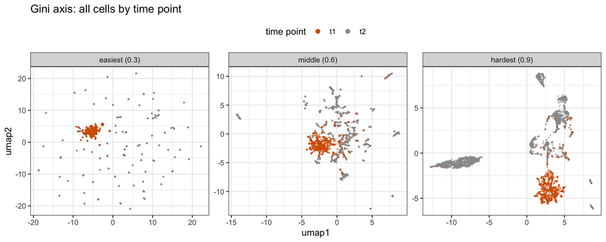

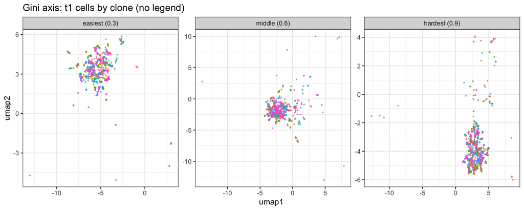

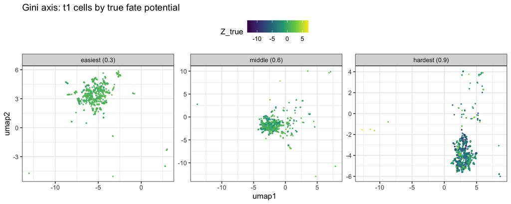

## 4.2 AED axis (fixed Gini 0.5)

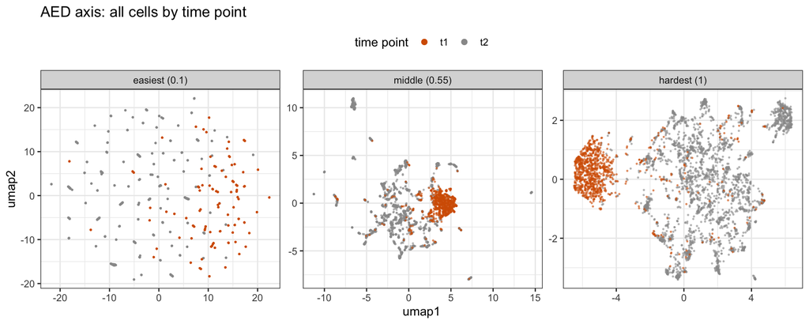

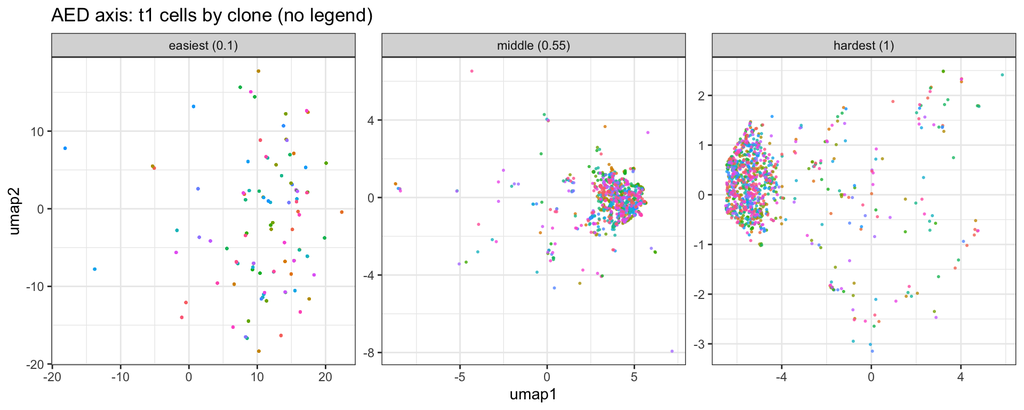

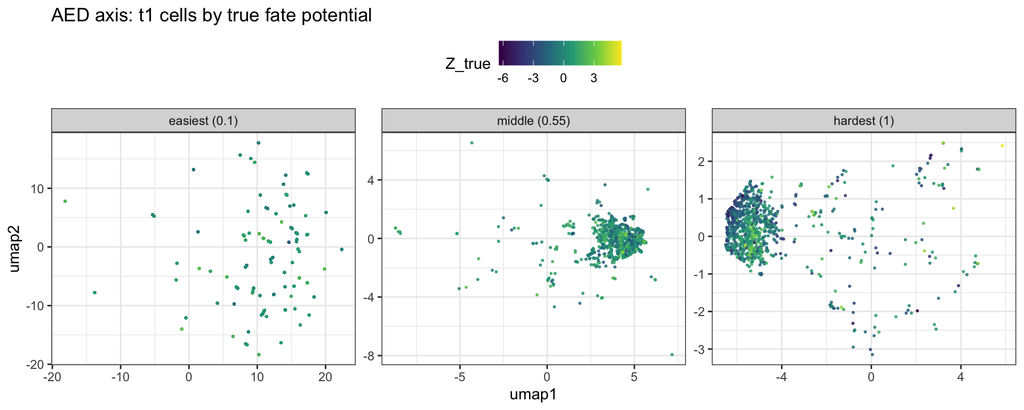

What to look for. The t1 and t2 populations barely overlap (the shared shift `δ` of about three t1 standard deviations on the non-causal coordinates). On the Gini axis the clone structure at t1 looks similar at every level — the axis moves the *fate potential’s* spread, not the geometry — while the fate coloring becomes more extreme toward Gini 0.9. On the AED axis the t1 clones go from tight patches (AED 0.1) to fully mixed (AED 1.0, where clones have no centre), while the fate potential stays a smooth gradient because the causal coordinate keeps the same share-free spread; the fate gradient is carried by one of 20 PCs, so it is not always aligned with the UMAP’s dominant directions.

# 5 How the simulation suite is set up

## 5.1 The two axes and their calibration

Both axes are stated in terms of a **realized** statistic, not a generator parameter:

- **Gini axis:** the t2-only Gini of the 100 clone sizes, zeros included (`gini_coef()`, identical to `dineq::gini.wtd`), targets `{0.3, 0.4, 0.5, 0.6, 0.7, 0.8, 0.9}`, mean squared AED held at 0.4. The first two passes ran `{0.2, 0.3, 0.4, 0.5, 0.6, 0.75, 0.9}`; the `_r2` ladder drops 0.2 (unreachable at the fixed AED, Section 7 of the round-1 report) and is denser between 0.5 and 0.9, where the comparators fall away.
- **AED axis:** the mean over clones of the per-clone squared AED (`SqDist_l / SqDist_random` in the shared embedding, computed as twice the sum of per-coordinate variances), targets `{0.1, 0.25, 0.4, 0.55, 0.7, 0.85, 1.0}`, t2 Gini held at 0.5.

Calibration of the Gini axis (`_r2` pass).

| Gini target | h2 initial | h2 final | re-centrings | check AED | s | tau | sigma_w | Gini (10 draws) |
| --- | --- | --- | --- | --- | --- | --- | --- | --- |
| 0.3 | 0.6 | 0.830 | 2 | 0.426 | 0.367 | 0.335 | 0.151 | 0.297 |
| 0.4 | 0.6 | 0.675 | 1 | 0.420 | 0.558 | 0.458 | 0.318 | 0.402 |
| 0.5 | 0.6 | 0.632 | 1 | 0.408 | 0.763 | 0.607 | 0.462 | 0.499 |
| 0.6 | 0.6 | 0.600 | 0 | 0.401 | 0.965 | 0.747 | 0.610 | 0.599 |
| 0.7 | 0.6 | 0.600 | 0 | 0.391 | 1.355 | 1.050 | 0.857 | 0.706 |
| 0.8 | 0.6 | 0.600 | 0 | 0.394 | 1.585 | 1.228 | 1.002 | 0.795 |
| 0.9 | 0.6 | 0.600 | 0 | 0.406 | 2.058 | 1.594 | 1.301 | 0.890 |

Calibration of the AED axis (`_r2` pass).

| AED target | h2 initial | h2 final | re-centrings | check AED | s | tau | sigma_w | Gini (10 draws) |
| --- | --- | --- | --- | --- | --- | --- | --- | --- |
| 0.10 | 0.90 | 1.000 | 3 | 0.130 | 0.619 | 0.619 | 0.000 | 0.504 |
| 0.25 | 0.75 | 0.832 | 1 | 0.267 | 0.652 | 0.595 | 0.267 | 0.505 |
| 0.40 | 0.60 | 0.652 | 1 | 0.405 | 0.804 | 0.649 | 0.474 | 0.504 |
| 0.55 | 0.45 | 0.450 | 0 | 0.572 | 0.847 | 0.568 | 0.628 | 0.502 |
| 0.70 | 0.30 | 0.300 | 0 | 0.706 | 0.991 | 0.543 | 0.829 | 0.507 |
| 0.85 | 0.15 | 0.106 | 1 | 0.847 | 1.159 | 0.377 | 1.096 | 0.504 |
| 1.00 | 0.00 | 0.000 | 3 | 0.932 | 1.253 | 0.000 | 1.253 | 0.499 |

## 5.2 Runs

Three passes, each 7 levels × 2 replicates × 2 axes = 28 datasets:

| Pass | Embedding | Gini ladder | CoSPAR extinct-clone t1 cells | Output suffix | Role |
| --- | --- | --- | --- | --- | --- |
| 1 | 10 PCs (memo as first written) | 0.2–0.9 | kept, bias 0.5 | none | the record of why the embedding dimension matters |
| 2 | 20 PCs | 0.2–0.9 | kept, bias 0.5 | `_pca20` | the record behind the review decisions |
| 3 | 20 PCs | 0.3–0.9 re-spaced | **excluded before CoSPAR** | `_r2` | the settled design; every headline number |

All three passes re-centre the AED calibration and use the corrected seed scheme except pass 1, which predates both. One dataset takes about a minute (generation 1 s, embedding 5 s, CYFER 3–6 s, lineage-DE 1 s, CoSPAR 15–45 s); a sweep is 12–14 minutes per axis and the two axes run concurrently.

# 6 Methods compared

All three methods see the same 1,000 t1 cells, the same clone labels, the same t2 clone sizes and, where they use one, the same embedding (PCA of log-normalized t1 counts; t2 cells projected with the t1 centre and rotation).

**CYFER.** `cyfer()` with 3-fold cross-validation over a 10-value λ path and `cyfer_finalize()` on the PCs, with the zero-count clones **kept** (the sim1–sim7 scripts drop them; here they carry the signal at high Gini). The per-gene statistic is the Spearman correlation of each gene’s log-normalized expression with `cell_imputed_score` over t1 cells.

**Lineage-DE.** Clones are split into “high” (t2 size above the *mean*) and “low”; every gene is compared between the t1 cells of high and low clones by the Wilcoxon rank-sum test, and the statistic is the rank-biserial correlation `2U / (n_H n_L) − 1`, computed for all genes at once from ranks and cross-checked against `stats::wilcox.test()` on five genes per dataset (U and p-value agree to 1e-6).

**The metric.** The truth is operational: `truth_g = Spearman(x_g, Z_true)` over the same t1 cells. The score of a method is `Spearman(m, truth)` over all 2,000 genes (Pearson and a Jaccard of BH `q < 0.05` sets are secondary columns). Per dataset the tables also record the correlation of each method’s per-cell fate score (`Z_hat`, fate bias) with `Z_true`, so a gene-level failure can be traced to the score or to the gene step.

# 7 Results

## 7.1 The headline curves (`_r2` pass)

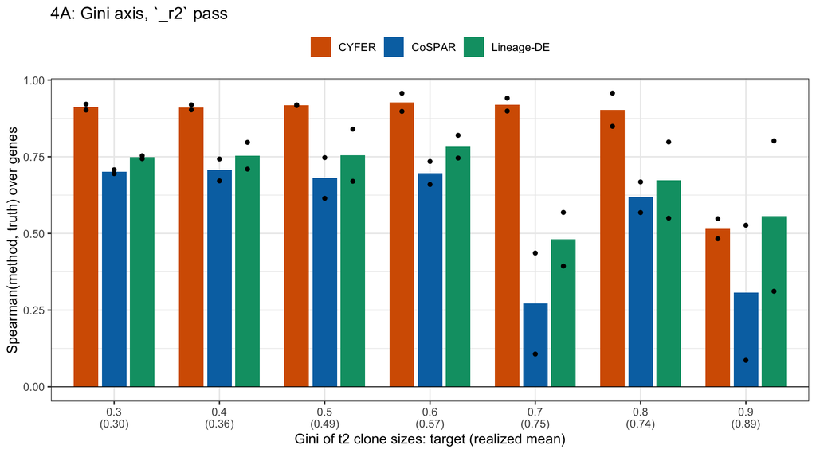

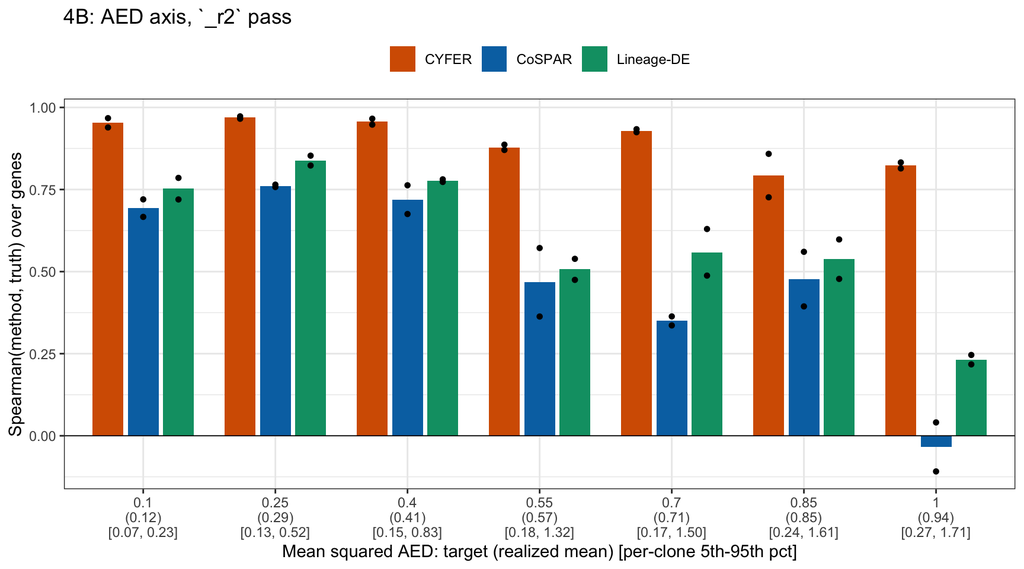

Gini axis, `_r2` pass: Spearman of each method’s per-gene vector with the truth, mean (SD) over 2 replicates.

| Gini target | CYFER | CoSPAR | Lineage-DE |
| --- | --- | --- | --- |
| 0.3 | 0.91 (0.01) | 0.70 (0.01) | 0.75 (0.01) |
| 0.4 | 0.91 (0.01) | 0.71 (0.05) | 0.75 (0.06) |
| 0.5 | 0.92 (0.00) | 0.68 (0.09) | 0.76 (0.12) |
| 0.6 | 0.93 (0.04) | 0.70 (0.05) | 0.78 (0.05) |
| 0.7 | 0.92 (0.03) | 0.27 (0.23) | 0.48 (0.12) |
| 0.8 | 0.90 (0.08) | 0.62 (0.07) | 0.67 (0.18) |
| 0.9 | 0.52 (0.05) | 0.31 (0.31) | 0.56 (0.35) |

AED axis, `_r2` pass: Spearman of each method’s per-gene vector with the truth, mean (SD) over 2 replicates.

| AED target | CYFER | CoSPAR | Lineage-DE |
| --- | --- | --- | --- |
| 0.10 | 0.95 (0.02) | 0.69 (0.04) | 0.75 (0.05) |
| 0.25 | 0.97 (0.01) | 0.76 (0.01) | 0.84 (0.02) |
| 0.40 | 0.96 (0.01) | 0.72 (0.06) | 0.78 (0.01) |
| 0.55 | 0.88 (0.01) | 0.47 (0.15) | 0.51 (0.05) |
| 0.70 | 0.93 (0.01) | 0.35 (0.02) | 0.56 (0.10) |
| 0.85 | 0.79 (0.09) | 0.48 (0.12) | 0.54 (0.08) |
| 1.00 | 0.82 (0.01) | -0.03 (0.11) | 0.23 (0.02) |

**Both panels show the intended gradient.** On the Gini axis CYFER stays at 0.90–0.93 from Gini 0.3 through 0.8 while lineage-DE holds at 0.75–0.78 through 0.6 and then degrades (0.48–0.67, with replicate SDs up to 0.35), and CoSPAR — now with the extinct-clone exclusion — holds near 0.70 through 0.6 and then becomes erratic (0.27, 0.62 and 0.31 at 0.7, 0.8 and 0.9, SDs up to 0.31). On the AED axis CYFER stays at 0.79–0.97 across the whole ladder while CoSPAR falls from 0.69–0.76 at the easy end to −0.03 at AED 1.0, and lineage-DE from 0.75–0.84 to 0.23. CYFER is the best method at every level of both axes except Gini 0.9, where all three land in an uninformative 0.3–0.6 band.

Three qualifications. At the top Gini level (0.9) CYFER’s gene-level score drops to 0.52 (SD 0.05) even though its fate score still correlates 0.82 with the truth: one clone holds about 1,100 of the 3,000 t2 cells and 25 clones are extinct, so the operational truth over 1,000 cells is itself dominated by a few dozen cells. Second, the extinct-clone exclusion moves CoSPAR’s fall-off point: with the 0.5-filled cells of the earlier passes CoSPAR dropped below 0.3 already at Gini 0.6, whereas with the exclusion it holds near 0.7 there, so **the “last easy level” of the Gini axis now reads 0.6** (all three ≥ 0.70) rather than the held 0.5; with two replicates that difference is within noise, and whether to move the fixed Gini from 0.5 to 0.6 for the final round is an open decision (memo Sections 8 and 9). The AED axis is unchanged: the last easy level is 0.4 (CoSPAR 0.47 and lineage-DE 0.51 at 0.55), the held value — and there the exclusion moves CoSPAR by at most +0.02 (CYFER and lineage-DE reproduce the earlier pass to four decimals, same seeds), so CoSPAR’s fall-off along the AED axis is genuine rather than extinct-clone bookkeeping. Third, everything above Gini 0.6 rests on two replicates with large comparator SDs and should not be over-read before the 20-replicate round.

## 7.2 The fate scores behind the gene calls

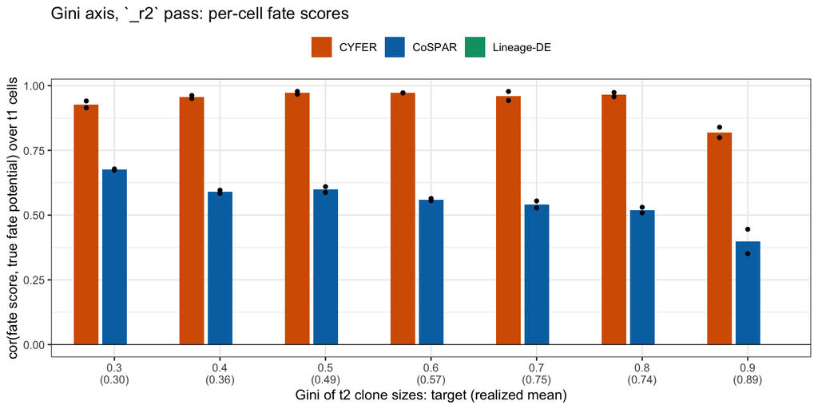

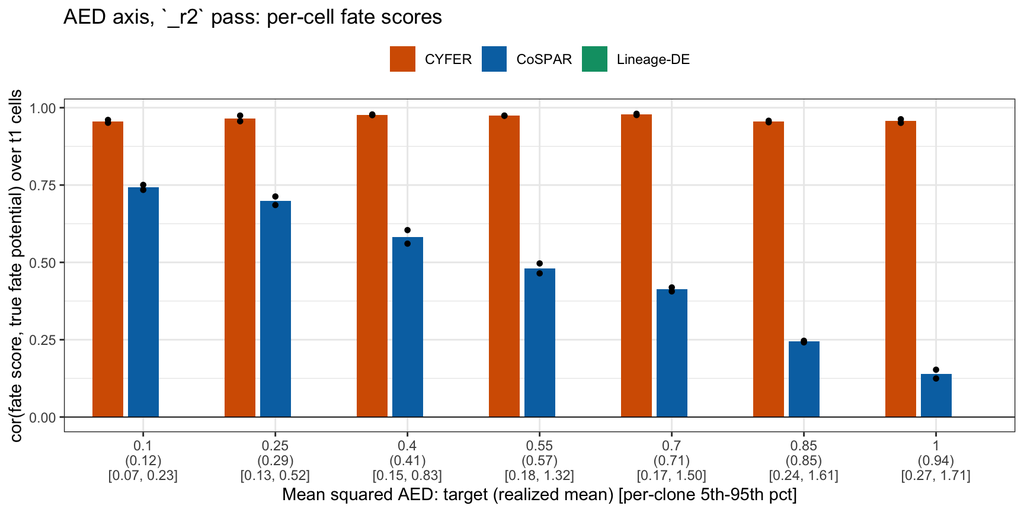

CYFER’s `cell_imputed_score` correlates 0.82–0.98 with `Z_true` at every level of both axes (0.82 at Gini 0.9, at least 0.93 everywhere else). CoSPAR’s fate bias — computed over the t1 cells it now actually scores, extinct-clone cells excluded — tops out near 0.7 at the easy end of both axes and decays to 0.14 at AED 1.0 and 0.40 at Gini 0.9; its ceiling is not the t2 drift (Section 7.6). **Lineage-DE has no bars in these plots because it does not compute a per-cell fate score at all**: it splits the clones into a high and a low group by their t2 sizes and compares the two groups of t1 cells gene by gene, so the only per-cell quantity it ever touches is the binary group label, and there is no natural per-cell number to correlate with `Z_true`. (One could assign every cell its clone’s t2 size, but that is a clone-level score, not a per-cell one, and it is not part of the lineage-DE recipe.) Its absence here is a property of the method, not a missing computation.

## 7.3 Secondary metrics

Gini axis, `_r2` pass: secondary metrics, mean over 2 replicates.

| Gini target | method | Pearson | Jaccard (q < 0.05) | converged / 2 |
| --- | --- | --- | --- | --- |
| 0.3 | CoSPAR | 0.87 | 0.66 | 2 |
| 0.3 | CYFER | 0.97 | 0.68 | 2 |
| 0.3 | Lineage-DE | 0.90 | 0.67 | 2 |
| 0.4 | CoSPAR | 0.87 | 0.61 | 2 |
| 0.4 | CYFER | 0.98 | 0.80 | 2 |
| 0.4 | Lineage-DE | 0.91 | 0.68 | 2 |
| 0.5 | CoSPAR | 0.87 | 0.58 | 2 |
| 0.5 | CYFER | 0.99 | 0.80 | 2 |
| 0.5 | Lineage-DE | 0.91 | 0.51 | 2 |
| 0.6 | CoSPAR | 0.83 | 0.39 | 2 |
| 0.6 | CYFER | 0.99 | 0.64 | 2 |
| 0.6 | Lineage-DE | 0.89 | 0.39 | 2 |
| 0.7 | CoSPAR | 0.68 | 0.25 | 2 |
| 0.7 | CYFER | 0.99 | 0.56 | 2 |
| 0.7 | Lineage-DE | 0.87 | 0.31 | 2 |
| 0.8 | CoSPAR | 0.80 | 0.39 | 2 |
| 0.8 | CYFER | 0.99 | 0.58 | 2 |
| 0.8 | Lineage-DE | 0.89 | 0.40 | 2 |
| 0.9 | CoSPAR | 0.44 | 0.13 | 2 |
| 0.9 | CYFER | 0.88 | 0.17 | 2 |
| 0.9 | Lineage-DE | 0.75 | 0.33 | 2 |

AED axis, `_r2` pass: secondary metrics, mean over 2 replicates.

| AED target | method | Pearson | Jaccard (q < 0.05) | converged / 2 |
| --- | --- | --- | --- | --- |
| 0.10 | CoSPAR | 0.87 | 0.34 | 2 |
| 0.10 | CYFER | 0.98 | 0.73 | 2 |
| 0.10 | Lineage-DE | 0.90 | 0.44 | 2 |
| 0.25 | CoSPAR | 0.92 | 0.51 | 2 |
| 0.25 | CYFER | 0.99 | 0.80 | 2 |
| 0.25 | Lineage-DE | 0.95 | 0.59 | 2 |
| 0.40 | CoSPAR | 0.86 | 0.49 | 2 |
| 0.40 | CYFER | 0.99 | 0.76 | 2 |
| 0.40 | Lineage-DE | 0.92 | 0.52 | 2 |
| 0.55 | CoSPAR | 0.80 | 0.58 | 2 |
| 0.55 | CYFER | 0.99 | 0.93 | 2 |
| 0.55 | Lineage-DE | 0.88 | 0.74 | 2 |
| 0.70 | CoSPAR | 0.69 | 0.42 | 2 |
| 0.70 | CYFER | 0.99 | 0.85 | 2 |
| 0.70 | Lineage-DE | 0.82 | 0.58 | 2 |
| 0.85 | CoSPAR | 0.44 | 0.16 | 2 |
| 0.85 | CYFER | 0.97 | 0.49 | 2 |
| 0.85 | Lineage-DE | 0.70 | 0.53 | 2 |
| 1.00 | CoSPAR | 0.18 | 0.08 | 2 |
| 1.00 | CYFER | 0.98 | 0.47 | 2 |
| 1.00 | Lineage-DE | 0.46 | 0.00 | 2 |

Every CYFER fit and every CoSPAR run converged (84 datasets across the three passes, plus the permutation and `τ_δ` checks; no `NULL` fit and no collapsed bias). The Jaccard column orders the methods the same way as the Spearman headline at almost every level but is noisier, as expected from a thresholded set.

## 7.4 Realized statistics and diagnostics

One row per level, averaged over the 2 replicates. (The realized statistics are dataset-level, so the three method rows of the summary table collapse to one row here; an earlier version of this table let the data frame’s original row names — 1, 4, 7, … , the positions of the first method row of each level — leak into the display, which meant nothing and is now suppressed.)

Gini axis, `_r2` pass: realized statistics per level, mean over 2 replicates.

| Gini target | Gini t2 | mean AED | AED 5th pct | AED 95th pct | largest clone | extinct clones | high clones | t1 cells excluded (CoSPAR) | Spearman(AED_l, Y_l) | PCA heritability |
| --- | --- | --- | --- | --- | --- | --- | --- | --- | --- | --- |
| 0.3 | 0.30 | 0.40 | 0.23 | 0.64 | 107.5 | 0.0 | 42.0 | 0 | 0.03 | 0.64 |
| 0.4 | 0.36 | 0.43 | 0.18 | 0.89 | 104.0 | 0.0 | 39.0 | 0 | 0.07 | 0.61 |
| 0.5 | 0.49 | 0.42 | 0.14 | 0.93 | 161.5 | 1.0 | 32.5 | 10 | -0.03 | 0.62 |
| 0.6 | 0.57 | 0.42 | 0.14 | 0.86 | 265.5 | 3.0 | 31.0 | 30 | -0.04 | 0.62 |
| 0.7 | 0.75 | 0.41 | 0.10 | 0.85 | 499.5 | 10.0 | 23.0 | 100 | 0.12 | 0.63 |
| 0.8 | 0.74 | 0.40 | 0.09 | 0.84 | 416.5 | 7.5 | 22.0 | 75 | -0.01 | 0.64 |
| 0.9 | 0.89 | 0.41 | 0.12 | 0.76 | 1139.0 | 25.0 | 11.5 | 250 | 0.11 | 0.63 |

AED axis, `_r2` pass: realized statistics per level, mean over 2 replicates.

| AED target | Gini t2 | mean AED | AED 5th pct | AED 95th pct | largest clone | extinct clones | high clones | t1 cells excluded (CoSPAR) | Spearman(AED_l, Y_l) | PCA heritability |
| --- | --- | --- | --- | --- | --- | --- | --- | --- | --- | --- |
| 0.10 | 0.49 | 0.12 | 0.07 | 0.23 | 190.0 | 0.0 | 28.5 | 0 | -0.02 | 0.89 |
| 0.25 | 0.49 | 0.29 | 0.13 | 0.52 | 157.0 | 0.5 | 39.0 | 5 | 0.02 | 0.74 |
| 0.40 | 0.55 | 0.41 | 0.15 | 0.83 | 333.5 | 1.0 | 28.0 | 10 | 0.09 | 0.63 |
| 0.55 | 0.47 | 0.57 | 0.18 | 1.32 | 216.0 | 0.0 | 34.5 | 0 | -0.07 | 0.49 |
| 0.70 | 0.45 | 0.71 | 0.17 | 1.50 | 137.0 | 0.5 | 33.5 | 5 | -0.04 | 0.36 |
| 0.85 | 0.53 | 0.85 | 0.24 | 1.61 | 249.5 | 1.0 | 28.0 | 10 | -0.10 | 0.24 |
| 1.00 | 0.50 | 0.94 | 0.27 | 1.71 | 275.0 | 1.0 | 29.5 | 10 | 0.00 | 0.16 |

- **The calibration holds** up to replicate scatter: the realized mean AED during the Gini sweep is 0.40–0.43 at every level, the realized Gini during the AED sweep is 0.45–0.55, and the realized Gini along its own axis is within 0.06 of target in the mean of two replicates (levels 0.4 and 0.8 realize 0.36 and 0.74), consistent with the ±0.05 per-replicate scatter of memo Section 4.2. The two floors are as expected: AED 0.1 realizes 0.12 and AED 1.0 realizes 0.94.
- **The per-clone AED spans the intended range**: at the top AED level the 5th–95th percentiles are 0.27–1.71 (the per-clone maximum exceeds 2).
- **The spread-size coupling is gone**, as the `"noncausal"` placement was meant to achieve: Spearman between a clone’s AED and its t2 size is between −0.10 and 0.12 at every level of both axes.
- **The Gini axis reaches the intended regime**: at Gini 0.9 the largest clone holds about 1,100 of 3,000 t2 cells and 25 clones are extinct; the lineage-DE high group shrinks from 42 clones at Gini 0.3 to about 12, and 250 of the 1,000 t1 cells are excluded from CoSPAR as extinct-clone cells (none are at the easy end of either axis).

## 7.5 Sanity checks (memo Section 7)

The memo’s Section 7 checklist, item by item. All but the label-permutation check are columns of the replicate tables, summarized above.

- **Label permutation** (`check_permutation_claude.R`): at the middle level of each axis (Gini 0.6, AED 0.55), the t1 cells’ clone labels were permuted before fitting — the t2 sizes stay attached to the clone names, so every method sees the same clone-size distribution with the feature–fate link severed — and all three methods were re-run on five fresh permutations per axis:

Label-permutation check, summarized over the permutations of each axis.

| axis | method | permutations | Spearman mean | Spearman min | Spearman max | cor(score, Z_true) min | cor(score, Z_true) max |
| --- | --- | --- | --- | --- | --- | --- | --- |
| gini | CYFER | 5 | -0.009 | -0.270 | 0.251 | -0.158 | 0.457 |
| gini | CoSPAR | 5 | 0.167 | 0.043 | 0.462 | -0.025 | 0.077 |
| gini | Lineage-DE | 5 | -0.055 | -0.197 | 0.186 | NA | NA |
| aed | CYFER | 5 | 0.031 | -0.355 | 0.613 | -0.376 | 0.392 |
| aed | CoSPAR | 5 | 0.033 | -0.370 | 0.195 | -0.017 | 0.083 |
| aed | Lineage-DE | 5 | 0.120 | 0.002 | 0.229 | NA | NA |

- **Realized statistics within tolerance**: Section 7.4; the calibration holds everywhere except the count-noise floor at the bottom of the AED axis.
- **Spread-size coupling** near 0 under `"noncausal"`: the `Spearman(AED_l, Y_l)` column of Section 7.4.
- **CYFER convergence** and **CoSPAR group sizes / collapsed-bias detection**: the `converged / 2` column of Section 7.3 (a constant CoSPAR bias would be reported as a failed run; none occurred).
- **t1 cells excluded from CoSPAR** per level: Section 7.4.
- **PCA heritability** per level, for cross-reference to sim3: Section 7.4.
- **Split-half reliability** was on the memo’s original list and has been dropped by decision (its Spearman form is 0.2–0.7 by construction with 1,900 null genes, so it cannot serve as the intended “well below 0.9” flag).

## 7.6 Does the clone-specific t2 drift explain CoSPAR’s ceiling?

If CoSPAR did poorly even at the easy end because of the clone-specific drift, `τ_δ` would be the thing to lower. At the easiest AED level (`h² = 0.9`, Gini 0.5, two seeds, 20 PCs; run during the `_pca20` pass, so before the extinct-clone exclusion, which touches few cells at this easy level) CoSPAR was re-run at `τ_δ ∈ {0, 0.3, 0.6, 1.2}`:

CoSPAR at the easiest AED level as the clone-specific t2 drift varies.

| tau_delta | Spearman, seed 2101 | cor(bias, Z_true), seed 2101 | Spearman, seed 2102 | cor(bias, Z_true), seed 2102 |
| --- | --- | --- | --- | --- |
| 0.0 | 0.90 | 0.72 | 0.66 | 0.71 |
| 0.3 | 0.90 | 0.72 | 0.63 | 0.70 |
| 0.6 | 0.90 | 0.72 | 0.59 | 0.68 |
| 1.2 | 0.89 | 0.72 | 0.56 | 0.65 |

## 7.7 The 10-PC pass: why the embedding dimension matters

This subsection compares the two 2026-09-22 passes (10 PCs versus 20 PCs, both on the original Gini ladder and before the CoSPAR exclusion) and is kept as the record behind the decision to adopt 20 PCs.

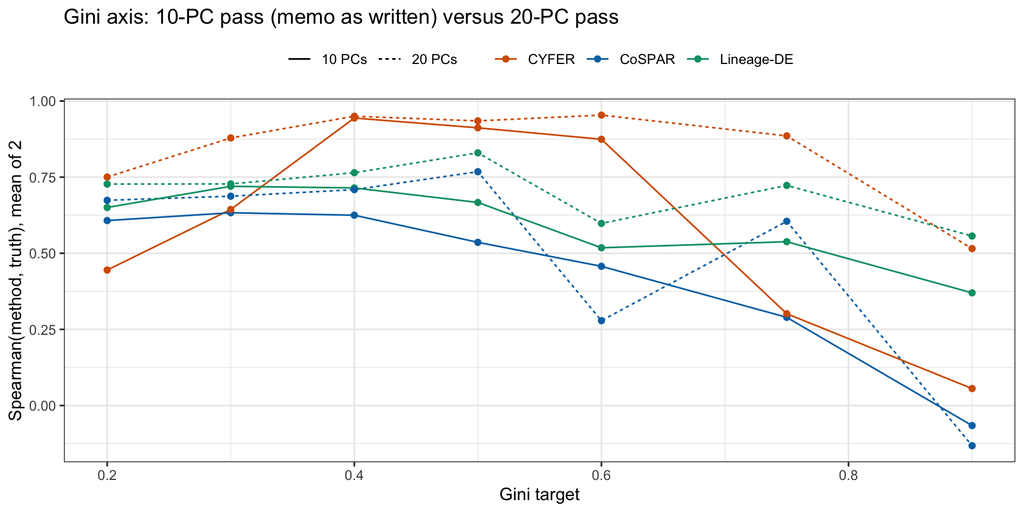

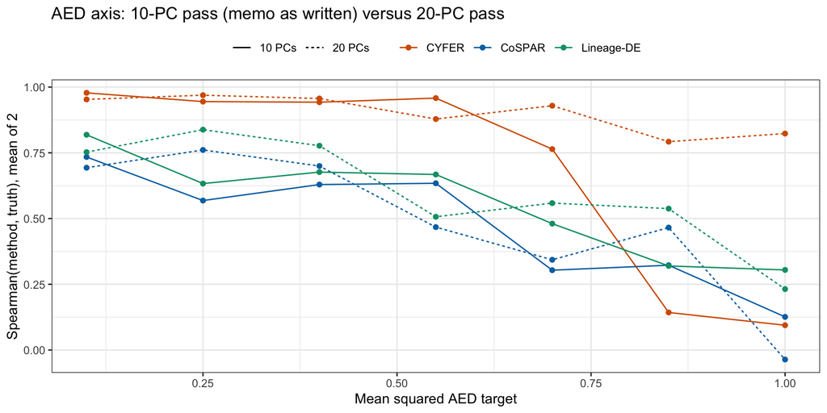

CYFER under the two embeddings: gene-level Spearman and fate-score correlation. (The 10-PC pass predates the re-centring and seed fixes, so its levels are not identical datasets.)

| axis | level | genes, 10 PCs | fate score, 10 PCs | genes, 20 PCs | fate score, 20 PCs |
| --- | --- | --- | --- | --- | --- |
| gini | 0.20 | 0.44 | 0.32 | 0.75 | 0.74 |
| gini | 0.30 | 0.64 | 0.49 | 0.88 | 0.91 |
| gini | 0.40 | 0.94 | 0.97 | 0.95 | 0.96 |
| gini | 0.50 | 0.91 | 0.98 | 0.93 | 0.96 |
| gini | 0.60 | 0.87 | 0.96 | 0.95 | 0.98 |
| gini | 0.75 | 0.30 | 0.33 | 0.89 | 0.96 |
| gini | 0.90 | 0.06 | 0.06 | 0.52 | 0.82 |
| aed | 0.10 | 0.98 | 0.97 | 0.95 | 0.96 |
| aed | 0.25 | 0.94 | 0.98 | 0.97 | 0.97 |
| aed | 0.40 | 0.94 | 0.98 | 0.96 | 0.98 |
| aed | 0.55 | 0.96 | 0.98 | 0.88 | 0.97 |
| aed | 0.70 | 0.76 | 0.61 | 0.93 | 0.98 |
| aed | 0.85 | 0.14 | 0.08 | 0.79 | 0.96 |
| aed | 1.00 | 0.09 | 0.01 | 0.82 | 0.96 |

With the memo’s 10-PC embedding CYFER collapses at the hard end of both axes (gene-level 0.06 at Gini 0.9 and 0.09 at AED 1.0, fate-score correlation 0.06 and 0.01) and at the weak-signal bottom of the Gini axis (0.44), and lineage-DE, which never uses the embedding, looks best at the top. The diagnosis, established with side experiments during the run:

- Fitting CYFER on the **true latent coordinates** instead of the PCs gives a fate-score correlation of 1.00 at every setting, so the model is not the problem.
- The causal axis loads on 100 genes with squared loadings around 0.58, while each of the nine non-causal coordinates loads on all 2,000 genes with squared loadings 0.0625, so in gene space the causal axis carries about half the variance of any non-causal one and is always the **weakest latent direction**. At the middle of either axis it sits on PC 10 (correlation 0.94 with the causal coordinate); at the corners it drops to PC 11 (correlation 0.83–0.96 with PC 11, at most 0.31 with any of PCs 1–10).
- The R² of `Z_true` on the first `k` PCs at the corners is 0.02–0.27 for `k ≤ 10` and 0.96–0.97 for `k ≥ 15`; at the middle it is 0.95 already at `k = 10`.

So a 10-PC embedding measures “does PCA keep the causal axis” rather than “does the method work”, and CoSPAR inherits the same loss. A 20-PC embedding (well under CYFER’s identifiability cap of about 60 features at 100 clones and 3 folds) keeps the axis everywhere, and every conclusion above is drawn from that pass.

# 8 Problems found in the first passes, and how each was resolved

The first two passes surfaced ten problems or open decisions; Kevin reviewed them (`additional_context/responses-to-Writeup21-trailblazing_round1.txt`) and every one is now resolved. The `_r2` pass implements the resolutions.

1. **The embedding dimension.** Ten PCs, equal to the latent dimension, do not recover the ten latent coordinates, because the causal coordinate is the weakest direction in gene space by construction (Section 7.7). *Resolved: the shared embedding is 20 PCs, now the default in the drivers and written into memo Section 6.2 with the reasoning.*
2. **The AED re-centring step was missing** from the first implementation, and the 10-PC Gini sweep ran at realized AED 0.53 and 0.45 at its two lowest levels instead of 0.4. *Resolved: the step is in `run_sweep()` and kept; memo Section 5 now states the update formula explicitly (`h² ← clamp(h² + (realized AED − target), 0, 1)`, re-bisect `s`, up to three times, tolerance 0.03).*
3. **The bottom Gini level is unreachable at fixed AED 0.4**: at Gini 0.2 the calibrated `s = 0.21` is so small that count noise dominates the embedding, and even `h² = 1` leaves the realized mean AED at 0.55. *Resolved: the Gini ladder is re-spaced to {0.3, 0.4, 0.5, 0.6, 0.7, 0.8, 0.9} — starting above the floor and denser where the comparators fall away (memo Section 3.3).*
4. **Seeds.** The first implementation seeded the generator’s three stages with `seed`, `seed + 1`, `seed + 2`, so consecutive replicates shared streams, and the calibration draws coincided with replicates. *Resolved and kept: sub-streams `10 · seed + {0, 1, 2}`, calibration draws at `+50` (memo Section 5).*
5. **CoSPAR and extinct clones.** With CoSPAR’s default `extend_Tmap_space = False`, t1 cells of extinct clones fall outside the transition map and receive a filled-in fate bias of exactly 0.5 — and these are precisely the lowest-fate cells, so the fill-in ranks them in the middle and handicaps CoSPAR at high Gini (34–40 % of t1 cells at Gini 0.9). *Resolved: these cells are excluded before CoSPAR runs, and the `_r2` pass trailblazes that setting (Section 7.1 — CoSPAR now holds near 0.7 through Gini 0.6 instead of dropping below 0.3, and its Gini-0.9 score rises from −0.13 to about 0.3); memo Sections 3.2 and 6.3 updated.*
6. **A constant CoSPAR bias** was scored as 0 rather than reported as missing. *Resolved: reported as a failed run, and noted here per pass — it has not occurred in any dataset of any pass.*
7. **Split-half reliability** as defined in the memo (Spearman over all genes) cannot serve as its “well below 0.9” flag, since it is 0.2–0.7 by construction. *Resolved: dropped from the code and the memo’s Section 7 checklist.*
8. **Tolerances disagreed** between memo Sections 4.2 (±0.03 on the realized Gini during the AED sweep) and 5 (±0.05 replicate variation). *Resolved: memo Section 4.2 now distinguishes the calibration tolerance on the mean (0.01) from replicate-to-replicate sampling variation (about ±0.05).*
9. **Tooling.** `devtools::install_local()` hung on the laptop; the package (1.0.3.0) was installed with `R CMD INSTALL` from a scratch copy, which Kevin approved as the standing workaround. `Rscript` parses a driver lazily, so a driver is never edited while it runs.
10. **CoSPAR’s ceiling of about 0.7** at the easy end of both axes means the figure’s easy end is “CYFER 0.95, others 0.7–0.8” rather than “all three near 1”; Section 7.6 shows this is a property of the barcode link, not of the drift. *Accepted as a real finding: CoSPAR is high (around 0.7) but not as high as CYFER at the easy end, which is the honest picture.*

# 9 What was and was not achieved

**Not achieved, or still open.**

- Two replicates per level leave the top of the Gini axis noisy; the final round’s 20 replicates are needed before anything firm is said about the top level, including whether the operational truth itself is the binding constraint there (memo Section 9).
- The final round has not run: it needs a `COSPAR_ENV` built on the Biostat cluster and a SLURM wrapper in the `sim3_heritability.slurm` pattern; the `τ_δ` supplementary row runs then.

# 10 Anything else

# 11 References

- Chen, X. E., Lin, K. Z., Schaff, D., et al. *Resolution of Selection Versus Adaptation in Cellular Evolution.* Manuscript in preparation for Nature Methods.
- Wang, S.-W., Herriges, M. J., Hurley, K., Kotton, D. N., Klein, A. M. (2022). CoSpar identifies early cell fate biases from single-cell transcriptomic and lineage information. *Nature Biotechnology* 40, 1066–1074. https://doi.org/10.1038/s41587-022-01209-1
- `simulation_design_claude.md` in this directory: the design memo the round implements.